# Jeremy Mulcahey: Assignment 4

[figure not shown]

```python
import numpy as np
import pandas as pd
import math
import matplotlib
import matplotlib.pyplot as plt
import statsmodels.tsa as tsa
from statsmodels.tsa.arima_model import ARIMA as arima
import datetime
import time
import matplotlib.dates as mdates
%matplotlib inline
```

[figure not shown]

```python
#read the csv file
ARIMA = np.loadtxt('data/HW4Data.csv', skiprows=1, delimiter=',')

#convert the numpy structure into a pandas DataFrame
ARIMAFrame = pd.DataFrame(ARIMA,columns=['time(sec)','ARIMA'])
```

```python
ARIMAts = pd.Series(ARIMAFrame.ARIMA, index = ARIMAFrame['time(sec)'])
```

```python
ARIMAts[0:]=ARIMAFrame.ARIMA
```

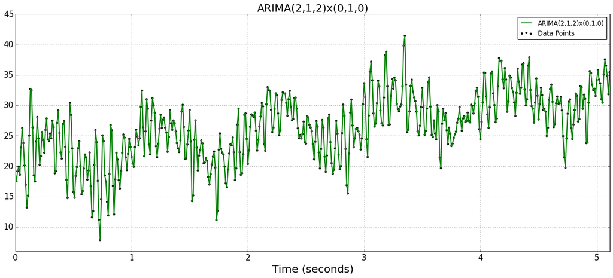

```python
#open a figure window and color it white
figure = plt.figure(figsize=(20,8))

plt.scatter(ARIMAFrame['time(sec)'],ARIMAFrame.ARIMA, s=10, c='black')
TSPlot = ARIMAts.plot(linewidth=2, c='green', ylim=(6,45))

#set x and y labels, title, and adjust thier sizes according
TSPlot.set_xlabel('Time (seconds)',fontsize=20)
TSPlot.set_title('ARIMA(2,1,2)x(0,1,0)',fontsize=20)
plt.tick_params(axis='both', labelsize=15)

TSPlot.legend(('ARIMA(2,1,2)x(0,1,0)','Data Points'), loc=1);
```

[figure not shown]

Tenet 1: The model does not have a constant mean over time, consider at least 1 order of differencing.

Tenet 2, Part A: Use one difference to correct for the linear trend present in the data.

Part B: Linear trend is present per significant positive autocorrelation at many lags. There also appears to be a seasonal component.

[figure not shown]

Part C: Lag-1 autocorrelation of once-differenced signal is positive, the series might need another order of differencing (seasonal).

[figure not shown]

Part D: Series is not over-differenced because lag-1 autocorrelation is about .3 which is much greater than -.5.

Part E: The model does have a time-varying trend, we can expect the model will have two orders of total differencing.

Tenet 3:

[figure not shown]

The optimal order of differencing here is 1 with a standard deviation of 3.43.

[figure not shown]

Tenet 4:  
Part A: This model has differencing, so far no constant term is needed.

Part B: The model has one order of differencing so far, but we expect an order of seasonal differencing. Thus, still no constant term. If no seasonal differencing term is added, this part of the Tenet needs to be re-evalutated.

Part C: Models with two or more orders (i.e. this model) do not typically include a constant term. Thus, no constant term is required. If no seasonal differencing term is added, this part of the Tenet needs to be re-evalutated.

[figure not shown]

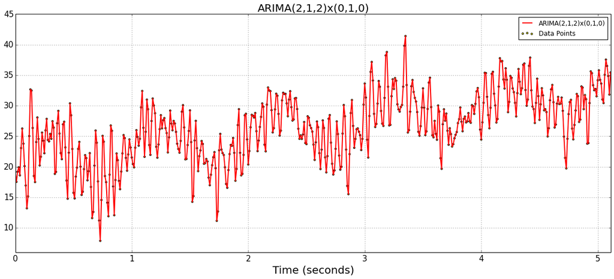

```python
#open a figure window and color it white
figure = plt.figure(figsize=(20,8))

TSPlot = ARIMAts.plot(linewidth=2, c='red', ylim=(6,45))
plt.scatter(ARIMAFrame['time(sec)'],ARIMAFrame.ARIMA, s=10, c='yellow')

#set x and y labels, title, and adjust thier sizes according
TSPlot.set_xlabel('Time (seconds)',fontsize=20)
TSPlot.set_title('ARIMA(2,1,2)x(0,1,0)',fontsize=20)
plt.tick_params(axis='both', labelsize=15)

TSPlot.legend(('ARIMA(2,1,2)x(0,1,0)','Data Points'), loc=1);
```

Tenet 8:  
Part A: Per the time series plot, there is a strong and consistent seasonal pattern with a season length of 1 second. With 100 time points per second, we have a season of 100 time points.  
Part B: Do not exceed two orders of differencing (seasonal and non-seasonal).

[figure not shown]

Tenet 5:  
Part A: PACF in 1st seasonal differenced of 1st differenced has a positive autocorrelation at lag-1. We should consider at least 1 AR term.  
Part B: Since the 2nd lag is also significant, before autocorrelation drastically drops at the third lag, we should consider an AR(2) model.

Tenet 6:  
Part A: There is a sharp cuttoff at lag-4. Consider an MA term.  
Part B: There are 3 apparent significant autocorrelations before the cutoff. Suggest MA(3) model.

Due to Minitab restrictions, I could no run the model ARIMA(2,1,3)x(0,1,0)100. Minitab required that I run ARIMA(2,1,2)x(0,1,0)100. This is the model:

[figure not shown]

No, there does not appear to be any need to modify the model.

[figure not shown]

Using the variances of the models:

```python
def AIC(k,var):
    return 2*k + math.log(var)

def AICc(k,n,AIC):
    return AIC + (2*k*(k+1))/(n-k-1)

def BIC(k,n,var):
    return k*math.log(n)-2*math.log(var)
```

```python
arima212AIC = AIC(4,24.464)
arima212AICc = AICc(4,411,arima212AIC)
arima112AIC = AIC(3,25.101)
arima112AICc = AICc(3,411,arima112AIC)
arima212BIC = BIC(4,411,24.464)
arima112BIC = BIC(3,411,25.101)
print("ARIMA(2,1,2)x(0,1,0)100 AICc:",arima212AICc)
print("ARIMA(1,1,2)x(0,1,0)100 AICc:",arima112AICc)
print("ARIMA(2,1,2)x(0,1,0)100 BIC:",arima212BIC)
print("ARIMA(1,1,2)x(0,1,0)100 BIC:",arima112BIC)
```

```
('ARIMA(2,1,2)x(0,1,0)100 AICc:', 11.197202649186707)
('ARIMA(1,1,2)x(0,1,0)100 AICc:', 9.222907685981571)
('ARIMA(2,1,2)x(0,1,0)100 BIC:', 17.679967559611523)
('ARIMA(1,1,2)x(0,1,0)100 BIC:', 11.609964271525559)
```

Although this model was built as a ARIMAARIMA(2,1,2)x(0,1,0)100, it appears that the tenets are allowing me to use a model with one less AR term. We'll stick with the original model, since e wants to know about the coefficients and removing a term would cause one of the original coefficients to now = 0.

[figure not shown]

The prediction interval and the predictions themselves look great, unfortunately Minitab doesn't.

[figure not shown]

The coefficients were suprinsingly different. Theta1 was slightly less for the model, as was theta2, Phi1 was significantly smaller, and Phi2 was significantly larger. I think the change in each much have balanced out to some degree because the model appears to be going a good job.

[figure not shown]

```python
#read the csv file
GC = np.loadtxt('data/geigerCounter300.csv', skiprows=1, delimiter=',')

#convert the numpy structure into a pandas DataFrame
GCFrame = pd.DataFrame(GC,columns=['date/time','Detections/5seconds'])
```

```python
GCFrame['date/times'] = mdates.num2date(GCFrame['date/time'])
GCts = pd.Series(index = GCFrame['date/times'])
GCts[0:] = GCFrame['Detections/5seconds']
```

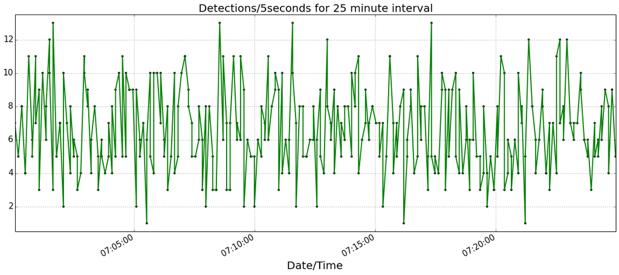

```python
#open a figure window and color it white
figure = plt.figure(figsize=(20,8))

TSPlot = GCts.plot(linewidth=2, c='green', ylim=(.5,13.5))
plt.scatter(GCFrame['date/time'],GCFrame['Detections/5seconds'], s=10, c='black')


#set x and y labels, title, and adjust thier sizes according
TSPlot.set_xlabel('Date/Time',fontsize=20)
TSPlot.set_title('Detections/5seconds for 25 minute interval' ,fontsize=20)
plt.tick_params(axis='both', labelsize=15)

#TSPlot.legend(('# of Detections/5seconds fits','Data Points'), loc=1);
```

Tenet 1: The model has a constant mean.

Tenet 2, Part A: There is no linear trend present in the data. No differencing needed thus far.

Part B: Confirmed the absence of a linear trend since we do not see significant positive autocorrelation at many lags in the acf below.

[figure not shown]

Part C, Part D, Part E, Part F, and Tenet 3: There is no apparent seasonal attribute to the data and we have determined there is no need for first order differencing thus far. Therefore, we do not need to evaluate these parts.

Tenet 4:  
Part A: This model has no differencing, so it's typical to include a constant term equal to the mean.

```python
print("Constant Term:", np.mean(GCts))
```

```
('Constant Term:', 6.6500000000000004)
```

Part B and Part C: No differencing.

Tenet 8:  
Part A: Per the time series plot, there is no consistent seasonal pattern.  
Part B: No differencing.

[figure not shown]

Tenet 5:  
Part A: There is no sharp cutoff and lag 1 autocorrelation is negative. Therefore, no AR term.  
Part B: No AR term.

Tenet 6:  
Part A: There is no sharp cuttoff. The autocorrelation at lag-1 is negative, but it is barely existent and far from significant. Therefore, no MA term.  
Part B: No MA term.

Tenet 7: There are no AR and no MA terms.

```python
mean = np.mean(GCts)
resids = GCts - mean
std = np.std(resids)
```

```python
def CIlow(mean,std,z):
    return mean - z*std

def CIhigh(mean,std, z):
    return mean+ z*std
```

Forecast for following hundred points:

```python
print('Forcast:',mean)
print('Upper Bound:', CIlow(mean,std,1.96))
print('Lower Bound:', CIhigh(mean, std, 1.96))
```

```
('Forcast:', 6.6500000000000004)
('Upper Bound:', 1.5612294870633718)
('Lower Bound:', 11.738770512936629)
```

```python
#read the csv file
GC2 = np.loadtxt('data/geigerCounter400.csv', skiprows=1, delimiter=',')

#convert the numpy structure into a pandas DataFrame
GC2Frame = pd.DataFrame(GC2,columns=['date/time','Detections/5seconds'])
```

```python
GC2Frame['date/times'] = mdates.num2date(GCFrame['date/time'])
GC2ts = pd.Series(index = GC2Frame['date/times'])
GC2ts[0:] = GC2Frame['Detections/5seconds']
```

```python
UpperTS = pd.Series(index = GC2Frame['date/times'][300:])
UpperTS[0:] = 1.561
LowerTS = pd.Series(index = GCFrame['date/times'][300:])
LowerTS[0:] = 11.739
```

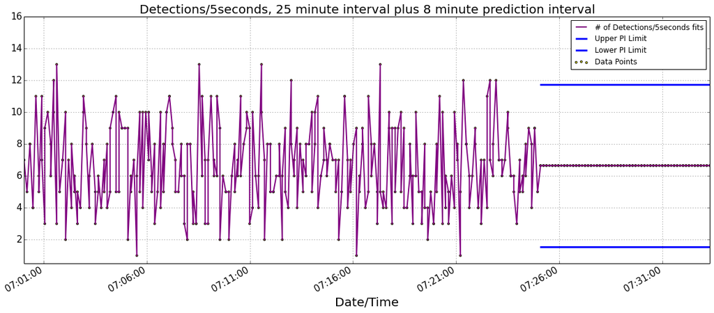

```python
#open a figure window and color it white
figure = plt.figure(figsize=(20,8))

TSPlot = GC2ts.plot(linewidth=2, c='purple', ylim=(.5,16))
plt.scatter(GC2Frame['date/time'],GC2Frame['Detections/5seconds'], s=10, c='yellow')
UpperTS.plot(linewidth = 3, c='blue')
LowerTS.plot(linewidth = 3, c='blue')

#set x and y labels, title, and adjust thier sizes according
TSPlot.set_xlabel('Date/Time',fontsize=20)
TSPlot.set_title('Detections/5seconds, 25 minute interval plus 8 minute prediction interval' ,fontsize=20)
plt.tick_params(axis='both', labelsize=15)

TSPlot.legend(('# of Detections/5seconds fits', 'Upper PI Limit', 'Lower PI Limit','Data Points'), loc='best');
```

[figure not shown]

```python
#read the csv file
CO2 = pd.read_csv('data/weeklyCO2.csv', delimiter=',')

#convert the numpy structure into a pandas DataFrame
CO2.columns = (['date','CO2'])
CO2ts = pd.Series(CO2['CO2'], index=CO2['date'])
CO2ts[0:] = CO2['CO2']
```

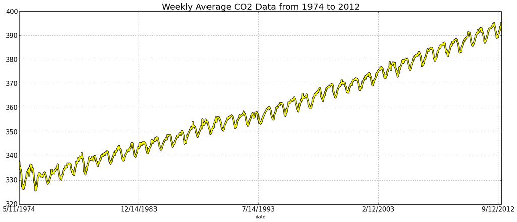

```python
#open a figure window and color it white
figure = plt.figure(figsize=(20,8))

TSPlot = CO2ts.plot(linewidth=4, c='black')
CO2ts.plot(linewidth=2, c='yellow')

TSPlot.set_title('Weekly Average CO2 Data from 1974 to 2012' ,fontsize=20)
plt.tick_params(axis='both', labelsize=15)
```

Observing the time series plot, and after completing problems 1 and 2, I can use some foresight here to know I will require an order of seasonal differencing.